Ignacio Palos Reynoso

Propedéutico : Tarea 1

# Ejercicios P.26

- Convertir de base 2 a base 10

$(10001110)_2$ = 128 + 8 + 4 + 2 = **142**

$(01011100)_2$ = 64 + 16 + 8 + 4 = **92**

- Convertir de base 10 a base 2

$(341)_{10}$ = 256 + 64 + 16 + 4 + 1 = $(101010101)_2$

- Convertir de binario a hexadecimal

$(1001 \; 0111 \; 1001 \; 1101)_2 = (9000)_{16} + (700)_{16} + (90)_{16} + (D)_{16} = (979D)_{16}$

$(1110 \; 0110 \; 1010 \; 0001)_2 = (E6A1)_{16}$

- Convertir de hexadecimal a binario

$0xAF35 = (1010 \; 1111 \; 0011 \; 0101)_2$

$(48D2)_{16} = (0100 \; 1000 \; 1101\; 0010)_2$

- Realice 2 corrimientos a la izquierda de $(1001 \; 0111 \; 1001 \; 1101)_2$ y una rotación a la derecha de $(1110 \; 0110 \; 1010 \; 0001)_2$ y realice la operación lógica AND

A = $(0101 \; 1110 \; 0111 \; 0100)_2$

B = $(1111 \; 0011 \; 0101 \; 0000)_2$

**A AND B** = $(0101 \; 0010 \; 0101 \; 0000)_2$

# Decodificador BCD

$a = BD + CD + \overline{BD} + A$

$b = \overline{CD} + \overline{B} + CD + A$

$c= \overline{C} + D + B $

$d= \overline{BD} + \overline{B}C + \overline{C}BD + C\overline{D}$

$f= \overline{CD} + B\overline{C}+ B\overline{D} +A$

$g= C\overline{D} + \overline{B}C +B\overline{D} + B\overline{C} +A$

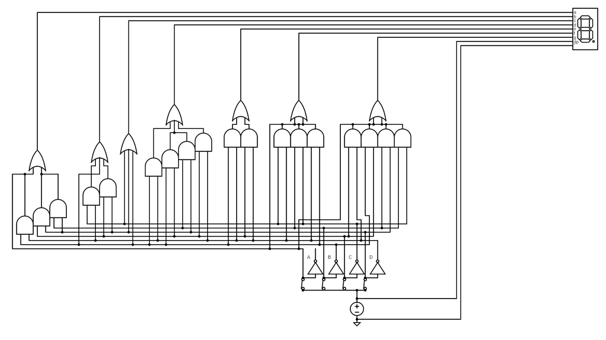

# Ejercicio P.106

Completar la tabla siguiente

| Q(t-1) | Q(t) | J | K | S | R | D | T |
| --- | --- | --- | --- | --- | --- | --- | --- |
| 0 | 0 | 0 | X | 0 | X | 0 | 0 |
| 0 | 1 | 1 | X | 1 | 0 | 1 | 1 |
| 1 | 0 | X | 1 | 0 | 1 | 0 | 1 |
| 1 | 1 | X | 0 | X | 0 | 1 | 0 |